# Reproducible Research - Peer Assessment 1

By: Mukesh Kanchan

## Introduction

It is now possible to collect a large amount of data about personal movement using activity monitoring devices such as a Fitbit, Nike Fuelband, or Jawbone Up. These type of devices are part of the “quantified self” movement - a group of enthusiasts who take measurements about themselves regularly to improve their health, to find patterns in their behavior, or because they are tech geeks. But these data remain under-utilized both because the raw data are hard to obtain and there is a lack of statistical methods and software for processing and interpreting the data.

## Loading and Processing the data

**Loading the data**

```r
# Set working directory
setwd("./data")

# Url of the data zip file
#fileURL <- "https://d396qusza40orc.cloudfront.net/repdata%2Fdata%2Factivity.zip"

# Downlaod zip file
#download.file(fileUrl, destfile='activity.zip', method='curl')

# Unzip the data file. Use read.csv() to load the data set into R
#unz("activity.zip", "activity.csv")
activity <- read.csv('activity.csv')
```

**Processing the data**

```r
# Convert date to date class
activity$date <- as.Date(activity$date, "%Y-%m-%d")

# Convert interval to numeric
activity$interval <- as.numeric(activity$interval)
```

## Mean total number of steps taken per day

**Histogram of the total number of steps taken each day**

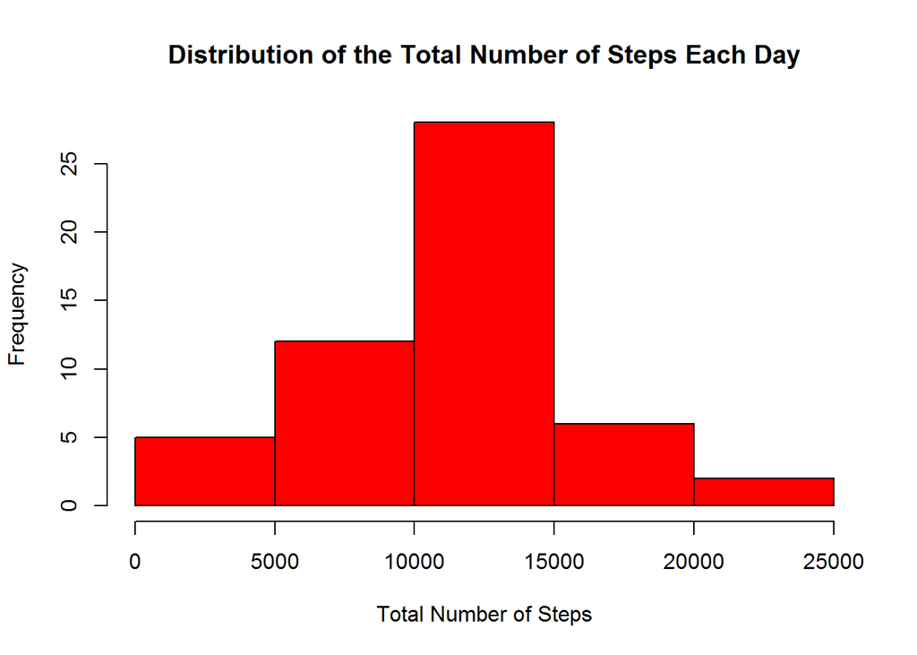

```r
# Use aggregate sum function to find the total number of steps each day
total.date.steps <- aggregate(steps ~ date, activity, sum, na.rm=T)

hist(total.date.steps$steps,
     col = "red",
     main = "Distribution of the Total Number of Steps Each Day",
     xlab = "Total Number of Steps")
```

**The mean and median total number of steps taken per day**

Mean total number of steps taken per day

```r
# NAs are removed already
mean(total.date.steps$steps)
```

```
## [1] 10766
```

Median total number of steps taken per day

```r
# NAs are removed already
median(total.date.steps$steps)
```

```
## [1] 10765
```

*The mean and median total number of steps per day are 10766.2 and 10765 steps respectively.*

## Average daily activity pattern

**Time Series Plot**

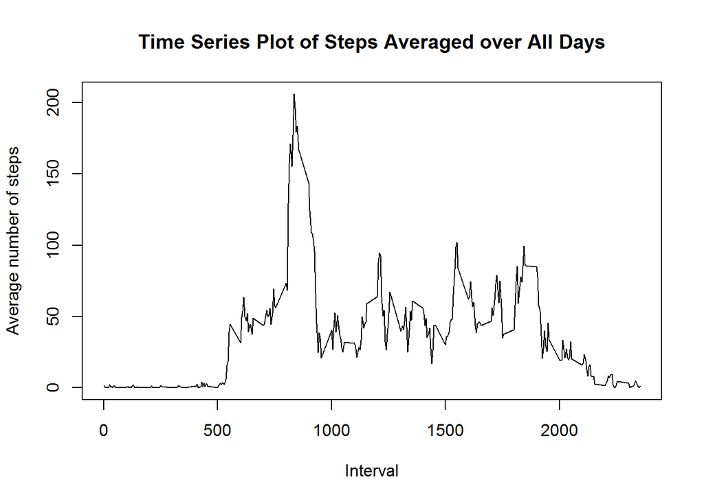

```r
# aggregate steps as interval to get average number of steps in an interval across all days
total.interval.steps <- aggregate(steps ~ interval, activity, mean, na.rm=T)

# generate the line plot of the 5-minute interval (x-axis) and the average number of
# steps taken, averaged across all days (y-axis)
plot(total.interval.steps$interval,
     total.interval.steps$steps,
     type="l",
     main="Time Series Plot of Steps Averaged over All Days",
     xlab="Interval",
     ylab="Average number of steps")
```

**Maximun Number of Steps**

```r
# row id of maximum average number of steps in an interval
maxAveStepsRow <- which.max(total.interval.steps$steps)

# interval with maximum average number of steps in an interval
total.interval.steps[maxAveStepsRow, ]
```

```
##     interval steps
## 104      835 206.2
```

*The interval 835 contains the maximum number of steps i.e. 206.1698*

## Input missing values

**Missing Values**

```r
# only step has NA values
sum(is.na(activity$steps))
```

```
## [1] 2304
```

*Total number of missing values in dataset: 2304*

**Filling in Missing Value**

Using the mean for the interval as a replacement for missing values.

```r
# merge activity and tableIntervalSteps dataframes
activity.missing <- merge(activity, total.interval.steps, by = "interval", sort = FALSE)

# rename columns
colnames(activity.missing) <- c('interval','steps','date','steps.mean')

# sort on date and interval
activity.missing <- activity.missing[with(activity.missing, order(date, interval)), ]

# replace in steps column NA with value in mean.steps column
activity.missing$steps[is.na(activity.missing$steps)] <- activity.missing$steps.mean[is.na(activity.missing$steps)]

# remove the column with the mean since it is no longer needed
activity.missing$steps.mean <- NULL

# data set has steps value in fraction
head(activity.missing)
```

```
##     interval   steps       date
## 1          0 1.71698 2012-10-01
## 63         5 0.33962 2012-10-01
## 128       10 0.13208 2012-10-01
## 205       15 0.15094 2012-10-01
## 264       20 0.07547 2012-10-01
## 327       25 2.09434 2012-10-01
```

**New Dataset with Filled-in Missing Values**

Creating new dataset with rounded steps and original order of columns

```r
#rounding steps to whole number
activity.missing$steps <- round(activity.missing$steps, digits=0)

#changing order of columns
activity.new <- activity.missing[, c(2, 3, 1)]

#new dataset
head(activity.new)
```

```
##     steps       date interval
## 1       2 2012-10-01        0
## 63      0 2012-10-01        5
## 128     0 2012-10-01       10
## 205     0 2012-10-01       15
## 264     0 2012-10-01       20
## 327     2 2012-10-01       25
```

**Histogram of the total number of steps taken each day**

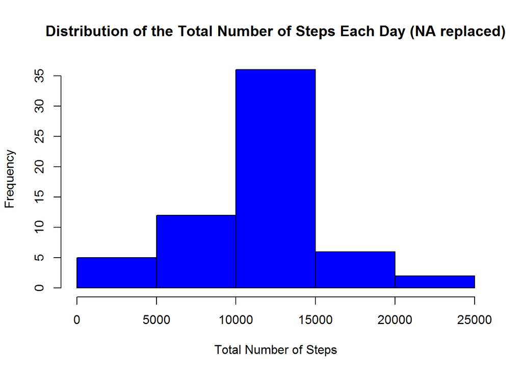

```r
# Use aggregate sum function to find the total number of steps each day
total.date.steps.new <- aggregate(steps ~ date, activity.new, sum, na.rm=T)

hist(total.date.steps.new$steps,
     col = "blue",
     main = "Distribution of the Total Number of Steps Each Day (NA replaced)",
     xlab = "Total Number of Steps")
```

**Mean and median total number of steps taken per day**

Mean total number of steps taken per day

```r
# No NAs here
mean(total.date.steps.new$steps)
```

```
## [1] 10766
```

Median total number of steps taken per day

```r
# No NAs here
median(total.date.steps.new$steps)
```

```
## [1] 10762
```

*The mean and median total number of steps per day after replacing ‘NA’ are 10765.6 and 10762 steps respectively.*

The Median is slightly lower when compared to the first part of the assignment.

## Differences in activity patterns between weekdays and weekends

**Create new factor variable for weekdays**

```r
# create a factor with the names of the days for all dates
activity.new$weekdays <- factor(format(activity.new$date, "%A"))

#replace variable with weekdays and weekends
levels(activity.new$weekdays) <- list(weekday = c("Monday", "Tuesday", "Wednesday", "Thursday", "Friday"), weekend = c("Saturday", "Sunday"))
```

**Panel Plot: Average number of steps taken on weekdays and weekends**

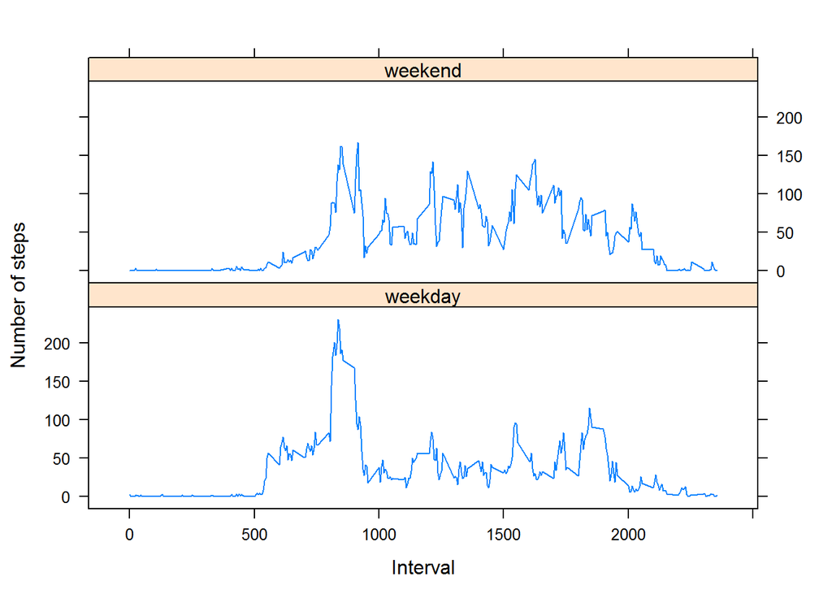

```r
# aggregate steps as interval to get average number of steps in an interval across weekdays and weekends
total.interval.steps.week <- aggregate(steps ~ weekdays * interval, activity.new, mean, na.rm=T)

#plotting using lattice system
library(lattice)
xyplot(total.interval.steps.week$steps ~ total.interval.steps.week$interval | total.interval.steps.week$weekday,
       layout = c(1, 2),
       type = "l",
       xlab = "Interval",
       ylab = "Number of steps")
```

*————End of Document————–*